# Allgemeine_Aufgaben_Gruppe_07

```r
# Daten verbinden & Verzug berechnen
Logistikverzug <- Komponente_K7 %>%
  select(IDNummer, Warenausgang) %>%
  inner_join(Logistikverzug_K7 %>% select(IDNummer, Wareneingang), by = "IDNummer") %>%
  mutate(Logistikverzug = as.numeric(Wareneingang - Warenausgang))

# Ergebnisse prüfen
head(Logistikverzug)
```

```
## # A tibble: 6 × 4
##   IDNummer      Warenausgang Wareneingang Logistikverzug
##   <chr>         <date>       <date>                <dbl>
## 1 K7-114-1142-1 2008-11-14   2008-11-17                3
## 2 K7-114-1142-2 2008-11-14   2008-11-17                3
## 3 K7-114-1142-3 2008-11-15   2008-11-18                3
## 4 K7-114-1142-4 2008-11-15   2008-11-18                3
## 5 K7-114-1142-5 2008-11-15   2008-11-17                2
## 6 K7-114-1142-6 2008-11-15   2008-11-19                4
```

Jetzt schauen wir uns die Häufigkeiten an

```r
# Absolute Häufigkeit (Wie oft kommt jeder Verzug vor?)
absolute_haeufigkeit <- table(Logistikverzug$Logistikverzug)

# Relative Häufigkeit (Anteil der jeweiligen Verzögerungen)
relative_haeufigkeit <- round(prop.table(absolute_haeufigkeit), 2)

# In einen DataFrame umwandeln, um besser damit arbeiten zu können
verzug_df <- data.frame(
  Logistikverzug = as.numeric(names(absolute_haeufigkeit)),  # Tage
  Absolute_Haeufigkeit = as.vector(absolute_haeufigkeit),   # Anzahl der Fälle
  Relative_Haeufigkeit = as.vector(relative_haeufigkeit)    # Anteil
)
```

```r
View(verzug_df)
```

absolute Häufigkeite visualisieren

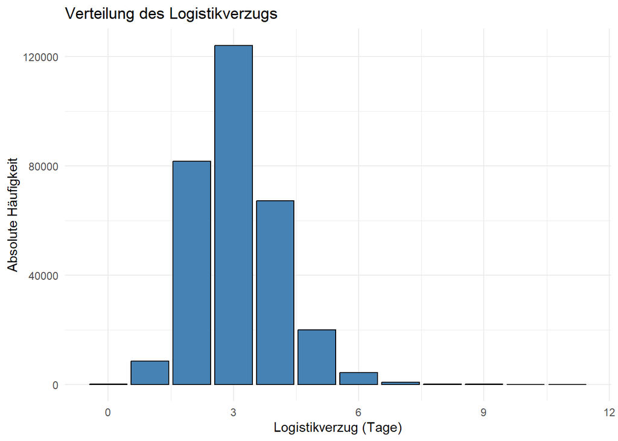

```r
ggplot(verzug_df, aes(x = Logistikverzug, y = Absolute_Haeufigkeit)) +
  geom_bar(stat = "identity", fill = "steelblue", color = "black") +
  labs(title = "Verteilung des Logistikverzugs",
       x = "Logistikverzug (Tage)",
       y = "Absolute Häufigkeit") +
  theme_minimal()
```

Wie viel Zeit vergeht mindestens/höchstens zwischen Warenausgang und Wareneingang (2 Punkte)?

```r
# Minimaler Logistikverzug
min_verzug <- min(Logistikverzug$Logistikverzug, na.rm = TRUE)

# Maximaler Logistikverzug
max_verzug <- max(Logistikverzug$Logistikverzug, na.rm = TRUE)

# Ergebnisse ausgeben
cat("Minimaler Logistikverzug:", min_verzug, "Tage\n")
```

```
## Minimaler Logistikverzug: 0 Tage
```

```r
cat("Maximaler Logistikverzug:", max_verzug, "Tage\n")
```

```
## Maximaler Logistikverzug: 11 Tage
```

Bestimmen Sie den Mittelwert des Logistikverzugs (1 Punkt).

```r
# Mittelwert des Logistikverzugs berechnen (in Tagen)
mean_verzug <- mean(Logistikverzug$Logistikverzug, na.rm = TRUE)

# Ganze Tage extrahieren
tage <- floor(mean_verzug)  # Ganze Tage

# Restliche Stunden berechnen
stunden_uebrig <- (mean_verzug - tage) * 24
stunden <- floor(stunden_uebrig)  # Ganze Stunden

# Restliche Minuten berechnen
minuten <- round((stunden_uebrig - stunden) * 60)  # Ganze Minuten

# Ergebnis ausgeben
cat("Durchschnittlicher Logistikverzug:", mean_verzug, "Tage\n")
```

```
## Durchschnittlicher Logistikverzug: 3.080437 Tage
```

```r
cat("Das entspricht:", tage, "Tagen,", stunden, "Stunden und", minuten, "Minuten\n")
```

```
## Das entspricht: 3 Tagen, 1 Stunden und 56 Minuten
```

Stellen Sie die Verteilung in geeigneter Weise mit Plotly dar (2 Punkte).

```r
library(plotly)
# Interaktives Histogramm mit Plotly
plotly_histogram <- plot_ly(
  data = Logistikverzug,
  x = ~Logistikverzug,
  type = "histogram",
  marker = list(color = "steelblue")) %>%
  layout(
    title = "Verteilung des Logistikverzugs",
    xaxis = list(title = "Logistikverzug (Tage)"),
    yaxis = list(title = "Häufigkeit"),
    bargap = 0.1
  )

# Plot anzeigen
plotly_histogram
```

[interactive chart not shown]

```r
# Daten für Plotly vorbereiten
plotly_data <- verzug_df  # DataFrame mit Häufigkeiten aus vorherigem Schritt

# Interaktives Balkendiagramm
plotly_barchart <- plot_ly(
  data = plotly_data,
  x = ~Logistikverzug,
  y = ~Absolute_Haeufigkeit,
  type = "bar",
  marker = list(color = "orange")
) %>%
  layout(
    title = "Absolute Häufigkeit des Logistikverzugs",
    xaxis = list(title = "Logistikverzug (Tage)"),
    yaxis = list(title = "Anzahl der Fälle"),
    bargap = 0.2
  )

# Plot anzeigen
plotly_barchart
```

[interactive chart not shown]

## Aufgabe 2:

Warum ist es sinnvoll, die Ihnen bereitgestellten Daten in separaten Dateien abzulegen und nicht alles in einer riesigen Tabelle abzuspeichern (4 Argumente)? Wie nennt sich das zugrunde liegende Datenbankkonzept? (3 Punkte)

```r
#Für eine bessere Datenorganisation und Verwaltbarkeit ist es sinnvoller die Daten in separaten Dateien oder Tabellen abzulegen. Bei einer großen Datenmenge ermöglicht diese Vorgehensweise eine effizientere Speicherung, Verwaltung und Bearbeitung der Daten. Wichtige Gründe hierfür sind die Redundanzvermeidung, eine bessere Wartbarkeit, eine einfache Such- und Abfrageoperation sowie die Skalierbarbeit und Performance.

#1.Redundanzvermeidung (Normalisierung)
# Daten werden in separate Tabellen aufgeteilt um redundante Daten zu vermeiden. In einer großen, monolithischen Tabelle kommen die Daten oft mehrfach vor, sodass es zu Inkonsistenzen und einem erhöhten Speicheraufwand kommen kann.

#2.Bessere Wartbarkeit
# Es ist es sinnvoller einzelne Dateien oder Tabellen zu haben, um diese leichter warten und aktualisieren zu können, weil Änderungen in einer Tabelle weniger Auswirkungen auf andere Daten haben.

#3. Einfache Such- und Abfrageoperation
# Kleinere und spezialisierte Tabellen ermöglichen eine schnellere Abfrage und Analyse, weil sie nur relevante Daten enthalten. Es muss keine große Tabelle durchsucht werden, was Zeitintensiver ist.

#4. Skalierbarkeit und Performance:
# Durch die Verteilung der Daten in mehreren Tabellen können Daten unabhängig voneinander skaliert und optimiert werden. Bei Arbeiten mit großen Datenmengen führt die Skalierbarkeit zu einer besseren Performance.

# Dieses zugrunde liegende Datenbankkonzept heißt Datenbanknormalisierung. Bei diesem Datenkonzept erfolgt die Aufteilung der Datenstruktur in mehrere Tabellen, die über Schlüssel (z. B. Primärschlüssel und Fremdschlüssel) miteinander verbunden werden. Hierbei soll eine Minimierung der Redundanz und eine Integrität der Daten gewährleistet werden.

#(Quelle: Chatgpt)
```

## Aufgabe 3:

Wie viele der Komponenten K7 landeten in Fahrzeugen, die in Wehr, Landkreis Waldshut zugelassen wurden? (3 Punkte)

```r
library(readr)
Zulassungen_alle_Fahrzeuge <- read_delim("Final_Data_Group_07/Zulassungen/Zulassungen_alle_Fahrzeuge.csv",
    delim = ";", escape_double = FALSE, trim_ws = TRUE)
```

```
## ──────────────────────────────────────────────────────── Delimiter: ";" chr
## (2): IDNummer, Gemeinden dbl (1): ...1 date (1): Zulassung
```

```r
head(Zulassungen_alle_Fahrzeuge)
```

```
## # A tibble: 6 × 4
##     ...1 IDNummer  Gemeinden Zulassung
##    <dbl> <chr>     <chr>     <date>
## 1 408097 11-1-11-1 DRESDEN   2009-01-01
## 2 408098 11-1-11-2 DRESDEN   2009-01-01
## 3      1 12-1-12-1 LEIPZIG   2009-01-01
## 4      2 12-1-12-2 LEIPZIG   2009-01-01
## 5      3 12-1-12-3 DORTMUND  2009-01-01
## 6      4 12-1-12-4 DORTMUND  2009-01-01
```

```r
# Datensatz filtern nach genau "Wehr" oder "Waldshut"
filtered_data <- Zulassungen_alle_Fahrzeuge %>%
  filter(Gemeinden %in% c("WEHR", "WEHR1"))

# Gefilterte Daten anzeigen
head(filtered_data)
```

```
## # A tibble: 6 × 4
##     ...1 IDNummer      Gemeinden Zulassung
##    <dbl> <chr>         <chr>     <date>
## 1 430238 11-1-11-14546 WEHR      2009-02-20
## 2 430239 11-1-11-14547 WEHR      2009-02-20
## 3 432038 11-1-11-15528 WEHR1     2009-02-20
## 4 432039 11-1-11-15529 WEHR1     2009-02-20
## 5 457755 11-1-11-30909 WEHR      2009-03-24
## 6 457756 11-1-11-30910 WEHR      2009-03-24
```

Relevante Tabellen mit Fahrzeugdaten importieren, welche uns zeigen, welche Fahrzeuge K7 Komponenten verbaut haben könnten

```r
Bestandteile_Fahrzeuge_OEM1_Typ11 <- read_delim("Final_Data_Group_07/Fahrzeug/Bestandteile_Fahrzeuge_OEM1_Typ11.csv",
    delim = ";", escape_double = FALSE, trim_ws = TRUE)
```

```
## ──────────────────────────────────────────────────────── Delimiter: ";" chr
## (5): ID_Karosserie, ID_Schaltung, ID_Sitze, ID_Motor, ID_Fahrzeug dbl (1): ...1
```

```r
head(Bestandteile_Fahrzeuge_OEM1_Typ11)
```

```
## # A tibble: 6 × 6
##    ...1 ID_Karosserie  ID_Schaltung       ID_Sitze          ID_Motor ID_Fahrzeug
##   <dbl> <chr>          <chr>              <chr>             <chr>    <chr>
## 1     1 K4-112-1121-3  K3SG1-105-1051-32  K2LE1-109-1091-2  K1BE1-1… 11-1-11-1
## 2     2 K4-112-1121-4  K3SG1-105-1051-141 K2ST1-109-1092-5  K1BE1-1… 11-1-11-2
## 3     3 K4-112-1121-7  K3SG1-105-1051-106 K2ST1-109-1092-57 K1BE1-1… 11-1-11-3
## 4     4 K4-112-1121-9  K3SG1-105-1051-21  K2ST1-109-1092-91 K1BE1-1… 11-1-11-4
## 5     5 K4-112-1121-11 K3SG1-105-1051-59  K2ST1-109-1092-4  K1BE1-1… 11-1-11-5
## 6     6 K4-112-1121-25 K3SG1-105-1051-132 K2ST1-109-1092-2  K1BE1-1… 11-1-11-6
```

```r
str(Bestandteile_Fahrzeuge_OEM1_Typ11)
```

```
## spc_tbl_ [1,977,164 × 6] (S3: spec_tbl_df/tbl_df/tbl/data.frame)
##  $ ...1         : num [1:1977164] 1 2 3 4 5 6 7 8 9 10 ...
##  $ ID_Karosserie: chr [1:1977164] "K4-112-1121-3" "K4-112-1121-4" "K4-112-1121-7" "K4-112-1121-9" ...
##  $ ID_Schaltung : chr [1:1977164] "K3SG1-105-1051-32" "K3SG1-105-1051-141" "K3SG1-105-1051-106" "K3SG1-105-1051-21" ...
##  $ ID_Sitze     : chr [1:1977164] "K2LE1-109-1091-2" "K2ST1-109-1092-5" "K2ST1-109-1092-57" "K2ST1-109-1092-91" ...
##  $ ID_Motor     : chr [1:1977164] "K1BE1-101-1011-7" "K1BE1-101-1011-12" "K1BE1-101-1011-38" "K1BE1-101-1011-97" ...
##  $ ID_Fahrzeug  : chr [1:1977164] "11-1-11-1" "11-1-11-2" "11-1-11-3" "11-1-11-4" ...
##  - attr(*, "spec")=
##   .. cols(
##   ..   ...1 = col_double(),
##   ..   ID_Karosserie = col_character(),
##   ..   ID_Schaltung = col_character(),
##   ..   ID_Sitze = col_character(),
##   ..   ID_Motor = col_character(),
##   ..   ID_Fahrzeug = col_character()
##   .. )
##  - attr(*, "problems")=<externalptr>
```

```r
Bestandteile_Fahrzeuge_OEM1_Typ12 <- read_delim("Final_Data_Group_07/Fahrzeug/Bestandteile_Fahrzeuge_OEM1_Typ12.csv",
    delim = ";", escape_double = FALSE, trim_ws = TRUE)
```

```
## ──────────────────────────────────────────────────────── Delimiter: ";" chr
## (5): ID_Karosserie, ID_Schaltung, ID_Sitze, ID_Motor, ID_Fahrzeug dbl (1): ...1
```

```r
head(Bestandteile_Fahrzeuge_OEM1_Typ12)
```

```
## # A tibble: 6 × 6
##    ...1 ID_Karosserie  ID_Schaltung      ID_Sitze          ID_Motor  ID_Fahrzeug
##   <dbl> <chr>          <chr>             <chr>             <chr>     <chr>
## 1     1 K5-112-1122-1  K3SG1-105-1051-4  K2ST1-109-1092-1  K1BE1-10… 12-1-12-1
## 2     2 K5-112-1122-11 K3AG1-105-1051-9  K2ST1-109-1092-16 K1BE1-10… 12-1-12-2
## 3     3 K5-112-1122-2  K3AG1-105-1051-23 K2ST1-109-1092-21 K1BE1-10… 12-1-12-3
## 4     4 K5-112-1122-3  K3AG1-106-1061-66 K2ST1-109-1092-70 K1BE1-10… 12-1-12-4
## 5     5 K5-112-1122-4  K3SG1-105-1051-8  K2ST1-109-1092-78 K1BE1-10… 12-1-12-5
## 6     6 K5-112-1122-6  K3SG1-105-1051-11 K2ST1-109-1092-82 K1BE1-10… 12-1-12-6
```

```r
str(Bestandteile_Fahrzeuge_OEM1_Typ12)
```

```
## spc_tbl_ [408,096 × 6] (S3: spec_tbl_df/tbl_df/tbl/data.frame)
##  $ ...1         : num [1:408096] 1 2 3 4 5 6 7 8 9 10 ...
##  $ ID_Karosserie: chr [1:408096] "K5-112-1122-1" "K5-112-1122-11" "K5-112-1122-2" "K5-112-1122-3" ...
##  $ ID_Schaltung : chr [1:408096] "K3SG1-105-1051-4" "K3AG1-105-1051-9" "K3AG1-105-1051-23" "K3AG1-106-1061-66" ...
##  $ ID_Sitze     : chr [1:408096] "K2ST1-109-1092-1" "K2ST1-109-1092-16" "K2ST1-109-1092-21" "K2ST1-109-1092-70" ...
##  $ ID_Motor     : chr [1:408096] "K1BE1-101-1011-90" "K1BE1-101-1011-2" "K1BE1-101-1011-8" "K1BE1-101-1011-11" ...
##  $ ID_Fahrzeug  : chr [1:408096] "12-1-12-1" "12-1-12-2" "12-1-12-3" "12-1-12-4" ...
##  - attr(*, "spec")=
##   .. cols(
##   ..   ...1 = col_double(),
##   ..   ID_Karosserie = col_character(),
##   ..   ID_Schaltung = col_character(),
##   ..   ID_Sitze = col_character(),
##   ..   ID_Motor = col_character(),
##   ..   ID_Fahrzeug = col_character()
##   .. )
##  - attr(*, "problems")=<externalptr>
```

```r
Bestandteile_Fahrzeuge_OEM2_Typ11 <- read_delim("Final_Data_Group_07/Fahrzeug/Bestandteile_Fahrzeuge_OEM1_Typ12.csv",
    delim = ";", escape_double = FALSE, trim_ws = TRUE)
```

```
## ──────────────────────────────────────────────────────── Delimiter: ";" chr
## (5): ID_Karosserie, ID_Schaltung, ID_Sitze, ID_Motor, ID_Fahrzeug dbl (1): ...1
```

```r
head(Bestandteile_Fahrzeuge_OEM2_Typ11)
```

```
## # A tibble: 6 × 6
##    ...1 ID_Karosserie  ID_Schaltung      ID_Sitze          ID_Motor  ID_Fahrzeug
##   <dbl> <chr>          <chr>             <chr>             <chr>     <chr>
## 1     1 K5-112-1122-1  K3SG1-105-1051-4  K2ST1-109-1092-1  K1BE1-10… 12-1-12-1
## 2     2 K5-112-1122-11 K3AG1-105-1051-9  K2ST1-109-1092-16 K1BE1-10… 12-1-12-2
## 3     3 K5-112-1122-2  K3AG1-105-1051-23 K2ST1-109-1092-21 K1BE1-10… 12-1-12-3
## 4     4 K5-112-1122-3  K3AG1-106-1061-66 K2ST1-109-1092-70 K1BE1-10… 12-1-12-4
## 5     5 K5-112-1122-4  K3SG1-105-1051-8  K2ST1-109-1092-78 K1BE1-10… 12-1-12-5
## 6     6 K5-112-1122-6  K3SG1-105-1051-11 K2ST1-109-1092-82 K1BE1-10… 12-1-12-6
```

```r
str(Bestandteile_Fahrzeuge_OEM2_Typ11)
```

```
## spc_tbl_ [408,096 × 6] (S3: spec_tbl_df/tbl_df/tbl/data.frame)
##  $ ...1         : num [1:408096] 1 2 3 4 5 6 7 8 9 10 ...
##  $ ID_Karosserie: chr [1:408096] "K5-112-1122-1" "K5-112-1122-11" "K5-112-1122-2" "K5-112-1122-3" ...
##  $ ID_Schaltung : chr [1:408096] "K3SG1-105-1051-4" "K3AG1-105-1051-9" "K3AG1-105-1051-23" "K3AG1-106-1061-66" ...
##  $ ID_Sitze     : chr [1:408096] "K2ST1-109-1092-1" "K2ST1-109-1092-16" "K2ST1-109-1092-21" "K2ST1-109-1092-70" ...
##  $ ID_Motor     : chr [1:408096] "K1BE1-101-1011-90" "K1BE1-101-1011-2" "K1BE1-101-1011-8" "K1BE1-101-1011-11" ...
##  $ ID_Fahrzeug  : chr [1:408096] "12-1-12-1" "12-1-12-2" "12-1-12-3" "12-1-12-4" ...
##  - attr(*, "spec")=
##   .. cols(
##   ..   ...1 = col_double(),
##   ..   ID_Karosserie = col_character(),
##   ..   ID_Schaltung = col_character(),
##   ..   ID_Sitze = col_character(),
##   ..   ID_Motor = col_character(),
##   ..   ID_Fahrzeug = col_character()
##   .. )
##  - attr(*, "problems")=<externalptr>
```

```r
Bestandteile_Fahrzeuge_OEM2_Typ12 <- read_delim("Final_Data_Group_07/Fahrzeug/Bestandteile_Fahrzeuge_OEM1_Typ12.csv",
    delim = ";", escape_double = FALSE, trim_ws = TRUE)
```

```
## ──────────────────────────────────────────────────────── Delimiter: ";" chr
## (5): ID_Karosserie, ID_Schaltung, ID_Sitze, ID_Motor, ID_Fahrzeug dbl (1): ...1
```

```r
head(Bestandteile_Fahrzeuge_OEM2_Typ12)
```

```
## # A tibble: 6 × 6
##    ...1 ID_Karosserie  ID_Schaltung      ID_Sitze          ID_Motor  ID_Fahrzeug
##   <dbl> <chr>          <chr>             <chr>             <chr>     <chr>
## 1     1 K5-112-1122-1  K3SG1-105-1051-4  K2ST1-109-1092-1  K1BE1-10… 12-1-12-1
## 2     2 K5-112-1122-11 K3AG1-105-1051-9  K2ST1-109-1092-16 K1BE1-10… 12-1-12-2
## 3     3 K5-112-1122-2  K3AG1-105-1051-23 K2ST1-109-1092-21 K1BE1-10… 12-1-12-3
## 4     4 K5-112-1122-3  K3AG1-106-1061-66 K2ST1-109-1092-70 K1BE1-10… 12-1-12-4
## 5     5 K5-112-1122-4  K3SG1-105-1051-8  K2ST1-109-1092-78 K1BE1-10… 12-1-12-5
## 6     6 K5-112-1122-6  K3SG1-105-1051-11 K2ST1-109-1092-82 K1BE1-10… 12-1-12-6
```

```r
str(Bestandteile_Fahrzeuge_OEM2_Typ12)
```

```
## spc_tbl_ [408,096 × 6] (S3: spec_tbl_df/tbl_df/tbl/data.frame)
##  $ ...1         : num [1:408096] 1 2 3 4 5 6 7 8 9 10 ...
##  $ ID_Karosserie: chr [1:408096] "K5-112-1122-1" "K5-112-1122-11" "K5-112-1122-2" "K5-112-1122-3" ...
##  $ ID_Schaltung : chr [1:408096] "K3SG1-105-1051-4" "K3AG1-105-1051-9" "K3AG1-105-1051-23" "K3AG1-106-1061-66" ...
##  $ ID_Sitze     : chr [1:408096] "K2ST1-109-1092-1" "K2ST1-109-1092-16" "K2ST1-109-1092-21" "K2ST1-109-1092-70" ...
##  $ ID_Motor     : chr [1:408096] "K1BE1-101-1011-90" "K1BE1-101-1011-2" "K1BE1-101-1011-8" "K1BE1-101-1011-11" ...
##  $ ID_Fahrzeug  : chr [1:408096] "12-1-12-1" "12-1-12-2" "12-1-12-3" "12-1-12-4" ...
##  - attr(*, "spec")=
##   .. cols(
##   ..   ...1 = col_double(),
##   ..   ID_Karosserie = col_character(),
##   ..   ID_Schaltung = col_character(),
##   ..   ID_Sitze = col_character(),
##   ..   ID_Motor = col_character(),
##   ..   ID_Fahrzeug = col_character()
##   .. )
##  - attr(*, "problems")=<externalptr>
```

alle relevanten Tabellen zusammenführen

```r
# Notwendige Bibliotheken laden
library(readr)
library(dplyr)

# CSV-Dateien einlesen
Bestandteile_Fahrzeuge_OEM1_Typ11 <- read_delim("Final_Data_Group_07/Fahrzeug/Bestandteile_Fahrzeuge_OEM1_Typ11.csv", delim = ";", escape_double = FALSE, trim_ws = TRUE)
```

```
## ──────────────────────────────────────────────────────── Delimiter: ";" chr
## (5): ID_Karosserie, ID_Schaltung, ID_Sitze, ID_Motor, ID_Fahrzeug dbl (1): ...1
```

```r
Bestandteile_Fahrzeuge_OEM1_Typ12 <- read_delim("Final_Data_Group_07/Fahrzeug/Bestandteile_Fahrzeuge_OEM1_Typ12.csv", delim = ";", escape_double = FALSE, trim_ws = TRUE)
```

```
## ──────────────────────────────────────────────────────── Delimiter: ";" chr
## (5): ID_Karosserie, ID_Schaltung, ID_Sitze, ID_Motor, ID_Fahrzeug dbl (1): ...1
```

```r
Bestandteile_Fahrzeuge_OEM2_Typ21 <- read_delim("Final_Data_Group_07/Fahrzeug/Bestandteile_Fahrzeuge_OEM2_Typ21.csv", delim = ";", escape_double = FALSE, trim_ws = TRUE)
```

```
## ──────────────────────────────────────────────────────── Delimiter: ";" chr
## (5): ID_Karosserie, ID_Schaltung, ID_Sitze, ID_Motor, ID_Fahrzeug dbl (1): ...1
```

```r
Bestandteile_Fahrzeuge_OEM2_Typ22 <- read_delim("Final_Data_Group_07/Fahrzeug/Bestandteile_Fahrzeuge_OEM2_Typ22.csv", delim = ";", escape_double = FALSE, trim_ws = TRUE)
# Alle Tabellen zusammenführen
Bestandteile_Fahrzeuge <- bind_rows(
  Bestandteile_Fahrzeuge_OEM1_Typ11,
  Bestandteile_Fahrzeuge_OEM1_Typ12,
  Bestandteile_Fahrzeuge_OEM2_Typ21,
  Bestandteile_Fahrzeuge_OEM2_Typ22
)

# Struktur der kombinierten Tabelle anzeigen
str(Bestandteile_Fahrzeuge)
```

```
## spc_tbl_ [3,204,104 × 7] (S3: spec_tbl_df/tbl_df/tbl/data.frame)
##  $ ...1         : num [1:3204104] 1 2 3 4 5 6 7 8 9 10 ...
##  $ ID_Karosserie: chr [1:3204104] "K4-112-1121-3" "K4-112-1121-4" "K4-112-1121-7" "K4-112-1121-9" ...
##  $ ID_Schaltung : chr [1:3204104] "K3SG1-105-1051-32" "K3SG1-105-1051-141" "K3SG1-105-1051-106" "K3SG1-105-1051-21" ...
##  $ ID_Sitze     : chr [1:3204104] "K2LE1-109-1091-2" "K2ST1-109-1092-5" "K2ST1-109-1092-57" "K2ST1-109-1092-91" ...
##  $ ID_Motor     : chr [1:3204104] "K1BE1-101-1011-7" "K1BE1-101-1011-12" "K1BE1-101-1011-38" "K1BE1-101-1011-97" ...
##  $ ID_Fahrzeug  : chr [1:3204104] "11-1-11-1" "11-1-11-2" "11-1-11-3" "11-1-11-4" ...
##  $ X1           : num [1:3204104] NA NA NA NA NA NA NA NA NA NA ...
##  - attr(*, "spec")=
##   .. cols(
##   ..   ...1 = col_double(),
##   ..   ID_Karosserie = col_character(),
##   ..   ID_Schaltung = col_character(),
##   ..   ID_Sitze = col_character(),
##   ..   ID_Motor = col_character(),
##   ..   ID_Fahrzeug = col_character()
##   .. )
##  - attr(*, "problems")=<externalptr>
```

```r
# Erste Zeilen der kombinierten Tabelle anzeigen
head(Bestandteile_Fahrzeuge)
```

```
## # A tibble: 6 × 7
##    ...1 ID_Karosserie  ID_Schaltung       ID_Sitze    ID_Motor ID_Fahrzeug    X1
##   <dbl> <chr>          <chr>              <chr>       <chr>    <chr>       <dbl>
## 1     1 K4-112-1121-3  K3SG1-105-1051-32  K2LE1-109-… K1BE1-1… 11-1-11-1      NA
## 2     2 K4-112-1121-4  K3SG1-105-1051-141 K2ST1-109-… K1BE1-1… 11-1-11-2      NA
## 3     3 K4-112-1121-7  K3SG1-105-1051-106 K2ST1-109-… K1BE1-1… 11-1-11-3      NA
## 4     4 K4-112-1121-9  K3SG1-105-1051-21  K2ST1-109-… K1BE1-1… 11-1-11-4      NA
## 5     5 K4-112-1121-11 K3SG1-105-1051-59  K2ST1-109-… K1BE1-1… 11-1-11-5      NA
## 6     6 K4-112-1121-25 K3SG1-105-1051-132 K2ST1-109-… K1BE1-1… 11-1-11-6      NA
```

Jetzt wollen wir wissen: Weche Autos haben K7 Komponenten verbaut? Wir joinen beide Tabellen

```r
# Tabellen zusammenführen über ID_Karosserie (Bestandteile_Fahrzeuge) und IDNummer (Komponente_K7)
fahrzeuge_mit_k7 <- Bestandteile_Fahrzeuge %>%
  inner_join(Komponente_K7, by = c("ID_Karosserie" = "IDNummer")) %>%
  select(ID_Karosserie, ID_Fahrzeug)  # Nur die relevanten Spalten behalten
```

Wir bereiten die Tablle Zulassung aller Fahrzeuge vor, so dass wir nur die Fahrzeuge sehen, welche in WEHR zugelassen wurden

```r
# Datensatz filtern nach genau "WEHR"
zulassungen_wehr <- Zulassungen_alle_Fahrzeuge %>%
  filter(Gemeinden == "WEHR")

# Ergebnis anzeigen
str(zulassungen_wehr)
```

```
## spc_tbl_ [130 × 4] (S3: spec_tbl_df/tbl_df/tbl/data.frame)
##  $ ...1     : num [1:130] 430238 430239 457755 457756 470364 ...
##  $ IDNummer : chr [1:130] "11-1-11-14546" "11-1-11-14547" "11-1-11-30909" "11-1-11-30910" ...
##  $ Gemeinden: chr [1:130] "WEHR" "WEHR" "WEHR" "WEHR" ...
##  $ Zulassung: Date[1:130], format: "2009-02-20" "2009-02-20" ...
##  - attr(*, "spec")=
##   .. cols(
##   ..   ...1 = col_double(),
##   ..   IDNummer = col_character(),
##   ..   Gemeinden = col_character(),
##   ..   Zulassung = col_date(format = "")
##   .. )
##  - attr(*, "problems")=<externalptr>
```

Jetzt gucken wir, welche Fahrzeuge in beiden Tabellen vorkommen und lassen uns die Anzahl der K7 Komponenten ausgeben

```r
# Tabellen zusammenführen über ID_Fahrzeug
fahrzeuge_k7_in_wehr <- fahrzeuge_mit_k7 %>%
  inner_join(zulassungen_wehr, by = c("ID_Fahrzeug" = "IDNummer"))

# Ergebnis anzeigen
print(fahrzeuge_k7_in_wehr)
```

```
## # A tibble: 6 × 5
##   ID_Karosserie     ID_Fahrzeug       ...1 Gemeinden Zulassung
##   <chr>             <chr>            <dbl> <chr>     <date>
## 1 K7-114-1142-25755 22-2-21-4893   2923266 WEHR      2009-08-24
## 2 K7-114-1142-25758 22-2-21-4894   2923267 WEHR      2009-08-24
## 3 K7-113-1132-27794 22-2-21-34477  3078582 WEHR      2013-11-01
## 4 K7-113-1132-27797 22-2-21-34478  3078583 WEHR      2013-11-01
## 5 K7-113-1132-44562 22-2-22-156359 3095464 WEHR      2014-04-01
## 6 K7-113-1132-44572 22-2-22-156360 3095465 WEHR      2014-04-01
```

```r
# Zählen der einzigartigen ID_Karosserie-Werte
anzahl_komponenten <- fahrzeuge_k7_in_wehr %>%
  pull(ID_Karosserie) %>%
  unique() %>%
  length() # Anzahl der einzigartigen Komponenten

# Ausgabe im Satz
cat("Es wurden", anzahl_komponenten, "K7 Komponenten in Fahrzeugen, welche in Wehr zugelassen wurden, verbaut.\n")
```

```
## Es wurden 6 K7 Komponenten in Fahrzeugen, welche in Wehr zugelassen wurden, verbaut.
```

## Aufgabe 4:

Welche Datentypen haben die Attribute der Zulassungstabelle „Zulassungen_aller_Fahrzeuge“? Erstellen Sie dazu eine Tabelle in Markdown. (2 Punkte)

```r
# Notwendige Bibliotheken laden
library(dplyr)
library(knitr)

# Datentypen der Spalten ermitteln
datentypen_zulassungen <- tibble(
  Attribut = names(Zulassungen_alle_Fahrzeuge),
  Datentyp = sapply(Zulassungen_alle_Fahrzeuge, function(x) class(x)[1]) # Nur den ersten Klassentyp ausgeben
)

# Markdown-Tabelle erstellen und ausgeben
kable(datentypen_zulassungen, format = "markdown", col.names = c("Attribut", "Datentyp"))
```

| Attribut | Datentyp |
| --- | --- |
| …1 | numeric |
| IDNummer | character |
| Gemeinden | character |
| Zulassung | Date |

## Aufgabe 5:

Sie wollen Ihre Applikation veröffentlichen. 1. Warum ist es gerade dann sinnvoll die Datensätze auf der Datenbank eines Servers abzulegen? 2. Warum können Sie die Datensätze nicht auf Ihrem persönlichen Computer ablegen? 3. Nennen Sie eine einfache Möglichkeit Ihre Applikation ihrem Kundenkreis zugänglich zu machen? (2 Argumente je Frage, insg. 3 Punkte)

```r
#1.Warum ist es sinnvoll, die Datensätze auf der Datenbank eines Servers abzulegen?

#Es ist sinnvoll, die Datensätze auf der Datenbank eines Servers abzulegen, weil bei einer    serverbasierten Datenbank die Daten gleichzeitig, zentral und sicher gespeichert werden können, sodass bei einer veröffentlichten Applikation immer mehrere Nutzer gleichzeitig darauf zugreifen können. Server laufen 24/7 und haben den Vorteil, dass sie leistungsfähiger und zuverlässiger als ein persönlicher Computer sind. Außerdem ist die Verwaltung von Backups, Skalierbarkeit und Sicherheit einfacher, wenn die Daten auf einem Server gespeichert sind.

#2.Warum können die Datensätze nicht auf dem persönlichen Computer gespeichert werden?

#Datensätze können nicht auf einem persönlichen Computer gespeichert werden, weil Nutzer keinen rund um die Uhr Zugriff auf die Daten haben, da der Computer nicht permanent online ist.Außerdem ist die Leistung eines einzelnen Computers zu gering, um viele Nutzer gleichzeitig zu bedienen. Das Risiko von einem Datenverlust ist bei einem persönlichen Computer viel höher, weil dieser weniger gegen Angriffe und Ausfälle geschützt ist.

#3.Einfache Möglichkeit, die Applikation dem Kundenkreis zugänglich zu machen:

#Einfache Möglichkeit, die Applikation dem Kundenkreis zugänglich zu machen wäre, die Applikation auf einem Webserver zu hosten und die Nutzer können sie dann über einen Webbrowser aufrufen. Es gibt Dienste wie AWS, Google Cloud und Heroku die diese Anwendungen schnell und einfach           bereitstellen. Es könnte auch eine mobile App zum Beispiel über den App Store oder Google Play  verteilt werden.

#(Quelle: Chatgpt)
```

## Aufgabe 6:

Am 11.08.2010 hat es einen Unfall mit Fahrerflucht gegeben. Von dem Kennzeichen des Unfallwagens fehlt jede Spur. Die Polizei bittet Sie um Hilfe, da Sie für das Kraftfahrtbundesamt arbeiten und fragt, wo das Fahrzeug mit der Karosseriebauteilnummer „K7-114-1142-31“ zugelassen wurde. (3 Punkte)

```r
# Tabellen zusammenführen über ID_Fahrzeug (Bestandteile_Fahrzeuge) und IDNummer (Zulassungen_alle_Fahrzeuge)
fahrzeug_unfall <- fahrzeuge_mit_k7 %>%
  inner_join(Zulassungen_alle_Fahrzeuge, by = c("ID_Fahrzeug" = "IDNummer")) %>%
  filter(ID_Karosserie == "K7-114-1142-31") # Nach der spezifischen Karosserie filtern
print(fahrzeug_unfall)
```

```
## # A tibble: 1 × 5
##   ID_Karosserie  ID_Fahrzeug    ...1 Gemeinden        Zulassung
##   <chr>          <chr>         <dbl> <chr>            <date>
## 1 K7-114-1142-31 22-2-22-2   2897636 ALLENDORF (EDER) 2009-01-02
```

```r
# Gemeinde extrahieren
gemeinde_unfall <- fahrzeug_unfall %>%
  pull(Gemeinden) %>% #Nur die Gemeinde extrahieren
  unique() #Falls mehrere Einträge existieren, nur eine eindeutige Gemeinde behalten

# Ausgabe in einem Satz
  cat("Das Fahrzeug mit der Karosseriebauteilnummer 'K7-114-1142-31' wurde in der Gemeinde", gemeinde_unfall, "zugelassen.\n")
```

```
## Das Fahrzeug mit der Karosseriebauteilnummer 'K7-114-1142-31' wurde in der Gemeinde ALLENDORF (EDER) zugelassen.
```